# 03_tidyverse_package

MinDong Sung

2021-04-09

# Tidyverse package

- `tidyverse` package tidyverse package는 여러 개의 package로 구성되어 있습니다. 유용한 다양한 기능들이 있습니다.

[figure not shown]

```r
library(tidyverse)
```

## 1. Read data

### 1-1. Read CSV file

`readr::read_csv()`

- 처음 1000개의 열로 데이터의 형태를 유추해서 추출한다.
- 따라서, 에러가 나는 경우는 column type을 정해줘야 한다.

```r
patients <- readr::read_csv(here('data/raw/tutorial_patients.csv'))
patients
```

```
## # A tibble: 50 x 5
##    subject_id gender anchor_age anchor_year dod
##         <dbl> <chr>       <dbl>       <dbl> <chr>
##  1   15256812 M              45        2133 <NA>
##  2   17334909 F              64        2133 <NA>
##  3   15701559 M              89        2131 2131.7.30
##  4   16051778 F              79        2159 <NA>
##  5   18137539 M              52        2142 <NA>
##  6   12294223 M              56        2145 <NA>
##  7   18316605 F              53        2165 <NA>
##  8   14133706 F              89        2149 <NA>
##  9   16113779 F              57        2154 2154.7.11
## 10   15386471 F              29        2117 <NA>
## # ... with 40 more rows
```

```r
patients <- readr::read_csv(here('data/raw/tutorial_patients.csv'),
                            col_types = cols(dod = col_date(format = "%Y.%m.%d")))
patients
```

```
## # A tibble: 50 x 5
##    subject_id gender anchor_age anchor_year dod
##         <dbl> <chr>       <dbl>       <dbl> <date>
##  1   15256812 M              45        2133 NA
##  2   17334909 F              64        2133 NA
##  3   15701559 M              89        2131 2131-07-30
##  4   16051778 F              79        2159 NA
##  5   18137539 M              52        2142 NA
##  6   12294223 M              56        2145 NA
##  7   18316605 F              53        2165 NA
##  8   14133706 F              89        2149 NA
##  9   16113779 F              57        2154 2154-07-11
## 10   15386471 F              29        2117 NA
## # ... with 40 more rows
```

### Tip) csv 문서가 깨지는 경우

1. UTF-8로 다시 저장 - excel에서 새이름으로 저장

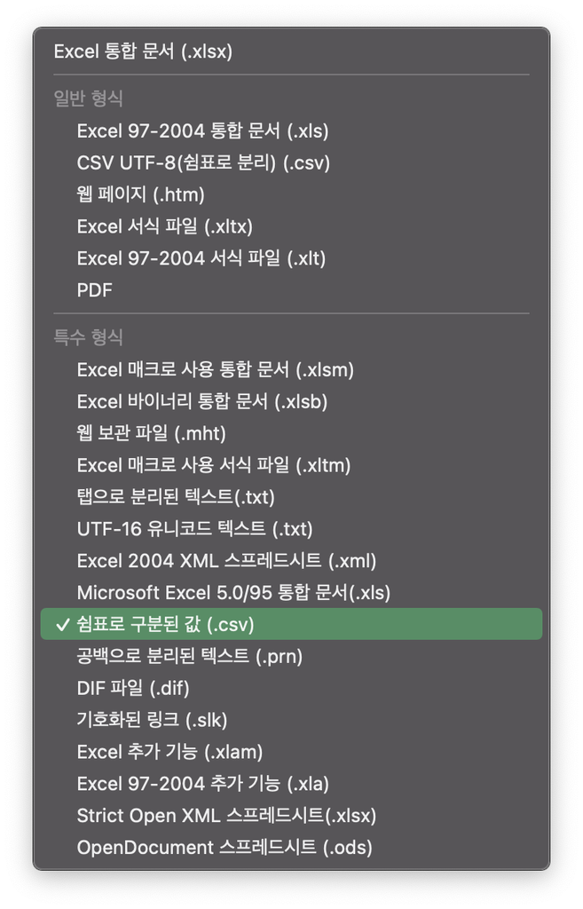

2. 한글이 포함된 문서 읽을 때 Error가 나는 경우
- 기존: UTF-8
- 변경: CP949 or EUC-KR

```r
readr::read_csv(file=here('data/raw/tutorial_patients_CP949.csv'))
```

```r
readr::read_csv(file=here('data/raw/tutorial_patients_CP949.csv'), locale = readr::locale(encoding = "EUC-KR"))
```

```
## # A tibble: 50 x 5
##    등록번호 성별  기준나이 기준년도 사망일자
##       <dbl> <chr>    <dbl>    <dbl> <chr>
##  1 15256812 M           45     2133 <NA>
##  2 17334909 F           64     2133 <NA>
##  3 15701559 M           89     2131 2131.7.30
##  4 16051778 F           79     2159 <NA>
##  5 18137539 M           52     2142 <NA>
##  6 12294223 M           56     2145 <NA>
##  7 18316605 F           53     2165 <NA>
##  8 14133706 F           89     2149 <NA>
##  9 16113779 F           57     2154 2154.7.11
## 10 15386471 F           29     2117 <NA>
## # ... with 40 more rows
```

### 1-2. Read Excel File

- `readxl::excel_sheets()`: 엑셀 파일에 포함된 spreadsheet의 종류 확인
- `readxl::read_excel()`: 엑셀파일을 읽을 때

```r
library(readxl)
readxl::excel_sheets(here('data/raw/tutorial_patients.xlsx'))
```

```
## [1] "tutorial_patients"
```

```r
readxl::read_excel(here('data/raw/tutorial_patients.xlsx'))
```

```
## # A tibble: 50 x 5
##    subject_id gender anchor_age anchor_year dod
##         <dbl> <chr>       <dbl>       <dbl> <dttm>
##  1   15256812 M              45        2133 NA
##  2   17334909 F              64        2133 NA
##  3   15701559 M              89        2131 2131-07-30 00:00:00
##  4   16051778 F              79        2159 NA
##  5   18137539 M              52        2142 NA
##  6   12294223 M              56        2145 NA
##  7   18316605 F              53        2165 NA
##  8   14133706 F              89        2149 NA
##  9   16113779 F              57        2154 2154-07-11 00:00:00
## 10   15386471 F              29        2117 NA
## # ... with 40 more rows
```

### Tip) 데이터를 복사 해서 R에 복사하는 방법(feat. datapasta)

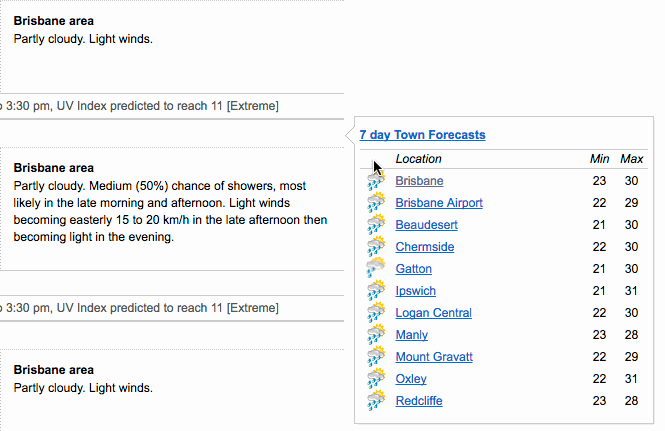

```r
library(datapasta)
table <- tibble::tribble(
           ~subject_id, ~gender, ~anchor_age, ~anchor_year,        ~dod,
             15256812L,     "M",         45L,        2133L,          NA,
             17334909L,     "F",         64L,        2133L,          NA,
             15701559L,     "M",         89L,        2131L, "2131.7.30",
             16051778L,     "F",         79L,        2159L,          NA,
             18137539L,     "M",         52L,        2142L,          NA,
             12294223L,     "M",         56L,        2145L,          NA,
             18316605L,     "F",         53L,        2165L,          NA,
             14133706L,     "F",         89L,        2149L,          NA,
             16113779L,     "F",         57L,        2154L, "2154.7.11",
             15386471L,     "F",         29L,        2117L,          NA,
             10575110L,     "F",         87L,        2160L,          NA,
             19004451L,     "M",         76L,        2132L,          NA,
             14851010L,     "M",         62L,        2119L,  "2119.8.4"
           )
```

## 2. Data Wrangling - **dplyr**, **tidyr** packages

참고) `package::command`

### 원본 데이터

```r
patients
```

```
## # A tibble: 50 x 5
##    subject_id gender anchor_age anchor_year dod
##         <dbl> <chr>       <dbl>       <dbl> <date>
##  1   15256812 M              45        2133 NA
##  2   17334909 F              64        2133 NA
##  3   15701559 M              89        2131 2131-07-30
##  4   16051778 F              79        2159 NA
##  5   18137539 M              52        2142 NA
##  6   12294223 M              56        2145 NA
##  7   18316605 F              53        2165 NA
##  8   14133706 F              89        2149 NA
##  9   16113779 F              57        2154 2154-07-11
## 10   15386471 F              29        2117 NA
## # ... with 40 more rows
```

### 2-1. **dplyr::select**

- 원하는 column을 선택하거나 column의 이름을 바꾸는데 사용

```r
select(patients, subject_id, gender, anchor_age)
```

```
## # A tibble: 50 x 3
##    subject_id gender anchor_age
##         <dbl> <chr>       <dbl>
##  1   15256812 M              45
##  2   17334909 F              64
##  3   15701559 M              89
##  4   16051778 F              79
##  5   18137539 M              52
##  6   12294223 M              56
##  7   18316605 F              53
##  8   14133706 F              89
##  9   16113779 F              57
## 10   15386471 F              29
## # ... with 40 more rows
```

```r
select(patients, 등록번호=subject_id, 성별=gender, 나이=anchor_age)
```

```
## # A tibble: 50 x 3
##    등록번호 성별   나이
##       <dbl> <chr> <dbl>
##  1 15256812 M        45
##  2 17334909 F        64
##  3 15701559 M        89
##  4 16051778 F        79
##  5 18137539 M        52
##  6 12294223 M        56
##  7 18316605 F        53
##  8 14133706 F        89
##  9 16113779 F        57
## 10 15386471 F        29
## # ... with 40 more rows
```

### 2-2. **dplyr::filter**

- 조건을 걸어 열을 선택할 때 사용

```r
filter(patients, gender == 'M', anchor_age > 65)
```

```
## # A tibble: 12 x 5
##    subject_id gender anchor_age anchor_year dod
##         <dbl> <chr>       <dbl>       <dbl> <date>
##  1   15701559 M              89        2131 2131-07-30
##  2   19004451 M              76        2132 NA
##  3   12192842 M              74        2151 NA
##  4   10860432 M              77        2179 NA
##  5   15890202 M              86        2156 NA
##  6   13651886 M              91        2111 NA
##  7   15188529 M              74        2141 NA
##  8   17511273 M              69        2124 NA
##  9   13260613 M              85        2140 NA
## 10   13444222 M              85        2142 NA
## 11   18667840 M              75        2123 NA
## 12   15798883 M              79        2110 NA
```

```r
filter(patients, (gender == 'M')| (anchor_age > 65))
```

```
## # A tibble: 34 x 5
##    subject_id gender anchor_age anchor_year dod
##         <dbl> <chr>       <dbl>       <dbl> <date>
##  1   15256812 M              45        2133 NA
##  2   15701559 M              89        2131 2131-07-30
##  3   16051778 F              79        2159 NA
##  4   18137539 M              52        2142 NA
##  5   12294223 M              56        2145 NA
##  6   14133706 F              89        2149 NA
##  7   10575110 F              87        2160 NA
##  8   19004451 M              76        2132 NA
##  9   14851010 M              62        2119 2119-08-04
## 10   16658317 F              76        2115 NA
## # ... with 24 more rows
```

```r
filter(patients, !is.na(dod))
```

```
## # A tibble: 5 x 5
##   subject_id gender anchor_age anchor_year dod
##        <dbl> <chr>       <dbl>       <dbl> <date>
## 1   15701559 M              89        2131 2131-07-30
## 2   16113779 F              57        2154 2154-07-11
## 3   14851010 M              62        2119 2119-08-04
## 4   15737550 M              62        2118 2119-05-22
## 5   14236258 M              59        2181 2191-09-20
```

### 2-3. **pipe %>%**

- 명령어를 이어서 적용해주는 역할을 한다.
- 단축키: `Ctrl` + `Shift` + `M`

```r
patients %>%
  select(subject_id, gender, anchor_age) %>%
  filter(gender == 'M', anchor_age > 65)
```

```
## # A tibble: 12 x 3
##    subject_id gender anchor_age
##         <dbl> <chr>       <dbl>
##  1   15701559 M              89
##  2   19004451 M              76
##  3   12192842 M              74
##  4   10860432 M              77
##  5   15890202 M              86
##  6   13651886 M              91
##  7   15188529 M              74
##  8   17511273 M              69
##  9   13260613 M              85
## 10   13444222 M              85
## 11   18667840 M              75
## 12   15798883 M              79
```

### 2-4. **dplyr::mutate()**

- 새로운 column을 만들거나 기존의 column을 변경시 사용
- `ifelse(조건문, 조건문 만족시 반환값, 조건문 불만족시 반환값)`

```r
patients %>% mutate(gender = ifelse(gender == 'M', 'Male', 'Female'))
```

```
## # A tibble: 50 x 5
##    subject_id gender anchor_age anchor_year dod
##         <dbl> <chr>       <dbl>       <dbl> <date>
##  1   15256812 Male           45        2133 NA
##  2   17334909 Female         64        2133 NA
##  3   15701559 Male           89        2131 2131-07-30
##  4   16051778 Female         79        2159 NA
##  5   18137539 Male           52        2142 NA
##  6   12294223 Male           56        2145 NA
##  7   18316605 Female         53        2165 NA
##  8   14133706 Female         89        2149 NA
##  9   16113779 Female         57        2154 2154-07-11
## 10   15386471 Female         29        2117 NA
## # ... with 40 more rows
```

```r
patients %>% mutate(death = ifelse(!is.na(dod), 'Death', 'Alive'))
```

```
## # A tibble: 50 x 6
##    subject_id gender anchor_age anchor_year dod        death
##         <dbl> <chr>       <dbl>       <dbl> <date>     <chr>
##  1   15256812 M              45        2133 NA         Alive
##  2   17334909 F              64        2133 NA         Alive
##  3   15701559 M              89        2131 2131-07-30 Death
##  4   16051778 F              79        2159 NA         Alive
##  5   18137539 M              52        2142 NA         Alive
##  6   12294223 M              56        2145 NA         Alive
##  7   18316605 F              53        2165 NA         Alive
##  8   14133706 F              89        2149 NA         Alive
##  9   16113779 F              57        2154 2154-07-11 Death
## 10   15386471 F              29        2117 NA         Alive
## # ... with 40 more rows
```

### 2-5. Combine multiple tables

#### 2-5-1. dplyr::bind_rows / dplyr::bind_cols

- table과 table을 합칠때.
  - 세로로 합칠 때는 `bind_rows`
  - 가로로 합칠 때는 `bind_cols`

```r
table1 <- readr::read_csv(here('data/raw/tutorial_patient1.csv'))
table2 <- readr::read_csv(here('data/raw/tutorial_patient2.csv'))
table3 <- readr::read_csv(here('data/raw/tutorial_patient3.csv'))
table4 <- readr::read_csv(here('data/raw/tutorial_patient4.csv'))
result <- bind_rows(table1, table2, table3, table4)
result
```

```
## # A tibble: 40 x 5
##    subject_id gender anchor_age anchor_year dod
##         <dbl> <chr>       <dbl>       <dbl> <chr>
##  1   19194449 M              57        2119 <NA>
##  2   12207593 M              43        2193 2194.5.6
##  3   10656173 F              33        2176 <NA>
##  4   10208468 M              87        2134 <NA>
##  5   10682002 M              55        2132 <NA>
##  6   18860233 F              54        2191 <NA>
##  7   16828280 M              84        2141 <NA>
##  8   12851972 F              91        2112 <NA>
##  9   14923903 M              81        2138 <NA>
## 10   10836215 M              62        2142 <NA>
## # ... with 30 more rows
```

- for (변수 in 리스트){}

```r
for (i in c(1, 2, 3)){
  print(i)
}
```

```
## [1] 1
## [1] 2
## [1] 3
```

- `glue::glue()`

```r
library(glue)
name = 'TRD'
year = '2021'

glue('Here we in {name} {year}')
```

```
## Here we in TRD 2021
```

```r
filenames = list.files(path=here('data/raw/'), pattern = "tutorial_patient[0-9]{1}.csv$")

result = tibble()
for (f in filenames){
  path = here(glue('data/raw/{f}'))
  table <- readr::read_csv(path)
  result = bind_rows(result, table)
}

result
```

```
## # A tibble: 40 x 5
##    subject_id gender anchor_age anchor_year dod
##         <dbl> <chr>       <dbl>       <dbl> <chr>
##  1   19194449 M              57        2119 <NA>
##  2   12207593 M              43        2193 2194.5.6
##  3   10656173 F              33        2176 <NA>
##  4   10208468 M              87        2134 <NA>
##  5   10682002 M              55        2132 <NA>
##  6   18860233 F              54        2191 <NA>
##  7   16828280 M              84        2141 <NA>
##  8   12851972 F              91        2112 <NA>
##  9   14923903 M              81        2138 <NA>
## 10   10836215 M              62        2142 <NA>
## # ... with 30 more rows
```

#### 2-5-2. dplyr::join

- key를 기준으로 두 테이블을 합친다.

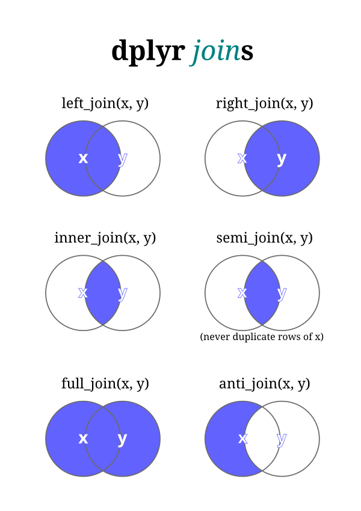

```r
icustays <- readr::read_csv(here('data/raw/tutorial_icustays.csv'))
patients <- readr::read_csv(here('data/raw/tutorial_patients.csv'))
icustays
```

```
## # A tibble: 50 x 7
##    subject_id  hadm_id  stay_id first_careunit          intime   outtime     los
##         <dbl>    <dbl>    <dbl> <chr>                   <chr>    <chr>     <dbl>
##  1   15256812 27228569 30957600 Medical Intensive Care~ 2133.6.~ 2133.6.2~  5.94
##  2   17334909 20212017 32339865 Medical Intensive Care~ 2133.11~ 2133.11.~  2.64
##  3   15701559 20996763 32652537 Medical/Surgical Inten~ 2131.7.~ 2131.7.2~ 13.0
##  4   16051778 28146406 39623620 Medical Intensive Care~ 2161.5.~ 2161.5.2~  5.25
##  5   18137539 21957886 37481477 Medical Intensive Care~ 2142.9.~ 2142.9.2~ 10.8
##  6   12294223 27700229 39327341 Coronary Care Unit (CC~ 2145.1.~ 2145.1.6~  2.72
##  7   18316605 28379893 36658714 Medical Intensive Care~ 2166.9.~ 2166.9.2~  2.73
##  8   14133706 28915263 33414119 Medical/Surgical Inten~ 2149.12~ 2149.12.~  1.30
##  9   16113779 25489328 39531653 Medical/Surgical Inten~ 2154.7.~ 2154.7.1~  1.04
## 10   15386471 28958740 35806450 Medical Intensive Care~ 2120.2.~ 2120.4.2~ 52.7
## # ... with 40 more rows
```

```r
patients
```

```
## # A tibble: 50 x 5
##    subject_id gender anchor_age anchor_year dod
##         <dbl> <chr>       <dbl>       <dbl> <chr>
##  1   15256812 M              45        2133 <NA>
##  2   17334909 F              64        2133 <NA>
##  3   15701559 M              89        2131 2131.7.30
##  4   16051778 F              79        2159 <NA>
##  5   18137539 M              52        2142 <NA>
##  6   12294223 M              56        2145 <NA>
##  7   18316605 F              53        2165 <NA>
##  8   14133706 F              89        2149 <NA>
##  9   16113779 F              57        2154 2154.7.11
## 10   15386471 F              29        2117 <NA>
## # ... with 40 more rows
```

```r
icustays %>% left_join(patients, by = 'subject_id')
```

```
## # A tibble: 50 x 11
##    subject_id  hadm_id  stay_id first_careunit     intime  outtime    los gender
##         <dbl>    <dbl>    <dbl> <chr>              <chr>   <chr>    <dbl> <chr>
##  1   15256812 27228569 30957600 Medical Intensive~ 2133.6~ 2133.6.~  5.94 M
##  2   17334909 20212017 32339865 Medical Intensive~ 2133.1~ 2133.11~  2.64 F
##  3   15701559 20996763 32652537 Medical/Surgical ~ 2131.7~ 2131.7.~ 13.0  M
##  4   16051778 28146406 39623620 Medical Intensive~ 2161.5~ 2161.5.~  5.25 F
##  5   18137539 21957886 37481477 Medical Intensive~ 2142.9~ 2142.9.~ 10.8  M
##  6   12294223 27700229 39327341 Coronary Care Uni~ 2145.1~ 2145.1.~  2.72 M
##  7   18316605 28379893 36658714 Medical Intensive~ 2166.9~ 2166.9.~  2.73 F
##  8   14133706 28915263 33414119 Medical/Surgical ~ 2149.1~ 2149.12~  1.30 F
##  9   16113779 25489328 39531653 Medical/Surgical ~ 2154.7~ 2154.7.~  1.04 F
## 10   15386471 28958740 35806450 Medical Intensive~ 2120.2~ 2120.4.~ 52.7  F
## # ... with 40 more rows, and 3 more variables: anchor_age <dbl>,
## #   anchor_year <dbl>, dod <chr>
```

### 2-6. dplyr::arrange()

- column 순서대로 정렬

```r
patients %>% head(10) %>% arrange(anchor_age)
```

```
## # A tibble: 10 x 5
##    subject_id gender anchor_age anchor_year dod
##         <dbl> <chr>       <dbl>       <dbl> <chr>
##  1   15386471 F              29        2117 <NA>
##  2   15256812 M              45        2133 <NA>
##  3   18137539 M              52        2142 <NA>
##  4   18316605 F              53        2165 <NA>
##  5   12294223 M              56        2145 <NA>
##  6   16113779 F              57        2154 2154.7.11
##  7   17334909 F              64        2133 <NA>
##  8   16051778 F              79        2159 <NA>
##  9   15701559 M              89        2131 2131.7.30
## 10   14133706 F              89        2149 <NA>
```

```r
patients %>% head(10) %>% arrange(desc(anchor_age))
```

```
## # A tibble: 10 x 5
##    subject_id gender anchor_age anchor_year dod
##         <dbl> <chr>       <dbl>       <dbl> <chr>
##  1   15701559 M              89        2131 2131.7.30
##  2   14133706 F              89        2149 <NA>
##  3   16051778 F              79        2159 <NA>
##  4   17334909 F              64        2133 <NA>
##  5   16113779 F              57        2154 2154.7.11
##  6   12294223 M              56        2145 <NA>
##  7   18316605 F              53        2165 <NA>
##  8   18137539 M              52        2142 <NA>
##  9   15256812 M              45        2133 <NA>
## 10   15386471 F              29        2117 <NA>
```

### 2-7. dplyr::group_by() / dplyr::summarize()

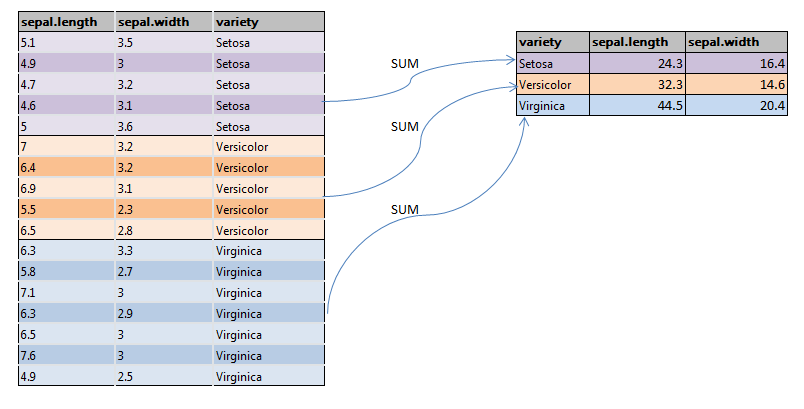

```r
icustays %>%
  left_join(patients, by = 'subject_id') %>%
  group_by(gender) %>%
  summarize(los_mean = mean(los),
            los_sd = sd(los),
            age_mean = mean(anchor_age),
            age_sd = sd(anchor_age))
```

```
## # A tibble: 2 x 5
##   gender los_mean los_sd age_mean age_sd
##   <chr>     <dbl>  <dbl>    <dbl>  <dbl>
## 1 F          4.88  10.7      60.3   18.0
## 2 M          3.52   4.05     65.1   17.3
```

```r
icustays %>%
  left_join(patients, by = 'subject_id') %>%
  group_by(first_careunit, gender) %>%
  summarize(los_mean = mean(los),
            los_sd = sd(los),
            age_mean = mean(anchor_age),
            age_sd = sd(anchor_age))
```

```
## # A tibble: 6 x 6
## # Groups:   first_careunit [3]
##   first_careunit                          gender los_mean los_sd age_mean age_sd
##   <chr>                                   <chr>     <dbl>  <dbl>    <dbl>  <dbl>
## 1 Coronary Care Unit (CCU)                F          5.58  7.17      62     9.66
## 2 Coronary Care Unit (CCU)                M          1.87  0.603     54.8  19.0
## 3 Medical Intensive Care Unit (MICU)      F          7.82 16.9       62.3  19.7
## 4 Medical Intensive Care Unit (MICU)      M          3.84  4.83      66.2  14.3
## 5 Medical/Surgical Intensive Care Unit (~ F          2.21  1.74      58.1  20.0
## 6 Medical/Surgical Intensive Care Unit (~ M          4.01  3.98      69.8  20.3
```

### 2-8. tidyr::pivot_wider() / tidyr::pivot_longer()

```r
labevents <- readr::read_csv(here('data/raw/tutorial_labevents.csv'))
labevents
```

```
## # A tibble: 7,647 x 5
##    subject_id  hadm_id charttime        label             value
##         <dbl>    <dbl> <chr>            <chr>             <dbl>
##  1   10394530 20598126 2191.7.3 7:02    White Blood Cells   6.8
##  2   10394530 20598126 2191.7.4 2:26    White Blood Cells   9.1
##  3   10575110 24932181 2160.11.29 4:55  White Blood Cells  18
##  4   10575110 24932181 2160.11.30 4:32  White Blood Cells  14.7
##  5   10575110 24932181 2160.11.30 17:50 White Blood Cells   9.7
##  6   10575110 24932181 2160.12.1 4:30   White Blood Cells   8
##  7   10575110 24932181 2160.12.2 4:44   White Blood Cells   6.5
##  8   10575110 24932181 2160.12.3 5:25   White Blood Cells   3.8
##  9   10575110 24932181 2160.12.4 5:21   White Blood Cells   5.9
## 10   10575110 24932181 2160.12.5 5:10   White Blood Cells   8.2
## # ... with 7,637 more rows
```

```r
labs <- icustays %>%
  left_join(labevents) %>%
  group_by(subject_id, hadm_id, stay_id,label) %>%
  filter(charttime == min(charttime)) %>%
  select(ends_with('id'), label, value, charttime, intime, outtime)
labs
```

```
## # A tibble: 611 x 8
## # Groups:   subject_id, hadm_id, stay_id, label [611]
##    subject_id  hadm_id  stay_id label        value charttime  intime   outtime
##         <dbl>    <dbl>    <dbl> <chr>        <dbl> <chr>      <chr>    <chr>
##  1   15256812 27228569 30957600 White Bloo~  18.6  2133.6.16~ 2133.6.~ 2133.6.2~
##  2   15256812 27228569 30957600 Chloride    108    2133.6.16~ 2133.6.~ 2133.6.2~
##  3   15256812 27228569 30957600 Alanine Am~  49    2133.6.16~ 2133.6.~ 2133.6.2~
##  4   15256812 27228569 30957600 Creatinine    0.8  2133.6.16~ 2133.6.~ 2133.6.2~
##  5   15256812 27228569 30957600 Platelet C~ 259    2133.6.16~ 2133.6.~ 2133.6.2~
##  6   15256812 27228569 30957600 pH            7.27 2133.6.16~ 2133.6.~ 2133.6.2~
##  7   15256812 27228569 30957600 Potassium     4.7  2133.6.16~ 2133.6.~ 2133.6.2~
##  8   15256812 27228569 30957600 Hematocrit   37.4  2133.6.16~ 2133.6.~ 2133.6.2~
##  9   15256812 27228569 30957600 Hemoglobin   12.5  2133.6.16~ 2133.6.~ 2133.6.2~
## 10   15256812 27228569 30957600 Asparate A~ 263    2133.6.16~ 2133.6.~ 2133.6.2~
## # ... with 601 more rows
```

```r
labs %>%
  pivot_wider(id_cols = c('subject_id', 'hadm_id', 'stay_id'), names_from = label) %>%
  select(ends_with('id'),
        `White Blood Cells`,
        `Red Blood Cells`,
        `Platelet Count`,
        `Alanine Aminotransferase (ALT)`,
        `Asparate Aminotransferase (AST)`,
        Creatinine,
        Sodium,
        Potassium,
        Chloride,
        Bicarbonate)
```

```
## # A tibble: 50 x 13
## # Groups:   subject_id, hadm_id, stay_id [50]
##    subject_id hadm_id stay_id `White Blood Ce~ `Red Blood Cell~ `Platelet Count`
##         <dbl>   <dbl>   <dbl>            <dbl>            <dbl>            <dbl>
##  1   15256812  2.72e7  3.10e7             18.6             4.23              259
##  2   17334909  2.02e7  3.23e7              5.1             6.73              146
##  3   15701559  2.10e7  3.27e7             13.7             3.91              193
##  4   16051778  2.81e7  3.96e7             18.6             3.47              377
##  5   18137539  2.20e7  3.75e7             11.2             2.65             1128
##  6   12294223  2.77e7  3.93e7              9.5             4.51              214
##  7   18316605  2.84e7  3.67e7             13.3             3.8               201
##  8   14133706  2.89e7  3.34e7             16.6             3.79              215
##  9   16113779  2.55e7  3.95e7              2.8             3.24              542
## 10   15386471  2.90e7  3.58e7              7.7             3.05              193
## # ... with 40 more rows, and 7 more variables:
## #   Alanine Aminotransferase (ALT) <dbl>,
## #   Asparate Aminotransferase (AST) <dbl>, Creatinine <dbl>, Sodium <dbl>,
## #   Potassium <dbl>, Chloride <dbl>, Bicarbonate <dbl>
```

```r
patients <- readr::read_csv(here('data/raw/tutorial_patients.csv'))
icustays <- readr::read_csv(here('data/raw/tutorial_icustays.csv'))
labevents <- readr::read_csv(here('data/raw/tutorial_labevents.csv'))
chartevents <- readr::read_csv(here('data/raw/tutorial_chartevents.csv'))

demographic_table <- icustays %>%
  left_join(patients, by = 'subject_id') %>%
  mutate(death = ifelse(!is.na(dod), 1, 0))

lab_table <- icustays %>%
  left_join(labevents, by = c('subject_id', 'hadm_id')) %>%
  group_by(subject_id, hadm_id, label) %>%
  filter(charttime == min(charttime)) %>%
  pivot_wider(id_cols = c('subject_id', 'hadm_id', 'stay_id'), names_from = label) %>%
  select(ends_with('id'),
        `White Blood Cells`,
        `Red Blood Cells`,
        `Platelet Count`,
        `Alanine Aminotransferase (ALT)`,
        `Asparate Aminotransferase (AST)`,
        Creatinine,
        Sodium,
        Potassium,
        Chloride,
        Bicarbonate)

vital_table <- icustays %>%
  left_join(chartevents, by = c('subject_id', 'hadm_id', 'stay_id')) %>%
  group_by(subject_id, hadm_id, stay_id, label) %>%
  filter(charttime == min(charttime), !is.na(value)) %>%
  pivot_wider(id_cols = c('subject_id', 'hadm_id', 'stay_id'), names_from = label) %>%
  select(ends_with('id'),
         `Non Invasive Blood Pressure systolic`,
         `Non Invasive Blood Pressure diastolic`,
         `Heart Rate`,
         `Respiratory Rate`,
         `Temperature Fahrenheit`,
         `Temperature Celsius`,
         `O2 saturation pulseoxymetry`
         )

result_table <- demographic_table %>%
  right_join(vital_table, by = c('subject_id', 'hadm_id', 'stay_id')) %>%
  right_join(lab_table, by = c('subject_id', 'hadm_id'))

result_table
```

```
## # A tibble: 50 x 30
##    subject_id  hadm_id stay_id.x first_careunit    intime  outtime    los gender
##         <dbl>    <dbl>     <dbl> <chr>             <chr>   <chr>    <dbl> <chr>
##  1   15256812 27228569  30957600 Medical Intensiv~ 2133.6~ 2133.6.~  5.94 M
##  2   17334909 20212017  32339865 Medical Intensiv~ 2133.1~ 2133.11~  2.64 F
##  3   15701559 20996763  32652537 Medical/Surgical~ 2131.7~ 2131.7.~ 13.0  M
##  4   16051778 28146406  39623620 Medical Intensiv~ 2161.5~ 2161.5.~  5.25 F
##  5   18137539 21957886  37481477 Medical Intensiv~ 2142.9~ 2142.9.~ 10.8  M
##  6   12294223 27700229  39327341 Coronary Care Un~ 2145.1~ 2145.1.~  2.72 M
##  7   18316605 28379893  36658714 Medical Intensiv~ 2166.9~ 2166.9.~  2.73 F
##  8   14133706 28915263  33414119 Medical/Surgical~ 2149.1~ 2149.12~  1.30 F
##  9   16113779 25489328  39531653 Medical/Surgical~ 2154.7~ 2154.7.~  1.04 F
## 10   15386471 28958740  35806450 Medical Intensiv~ 2120.2~ 2120.4.~ 52.7  F
## # ... with 40 more rows, and 22 more variables: anchor_age <dbl>,
## #   anchor_year <dbl>, dod <chr>, death <dbl>,
## #   Non Invasive Blood Pressure systolic <dbl>,
## #   Non Invasive Blood Pressure diastolic <dbl>, Heart Rate <dbl>,
## #   Respiratory Rate <dbl>, Temperature Fahrenheit <dbl>,
## #   Temperature Celsius <dbl>, O2 saturation pulseoxymetry <dbl>,
## #   stay_id.y <dbl>, White Blood Cells <dbl>, Red Blood Cells <dbl>,
## #   Platelet Count <dbl>, Alanine Aminotransferase (ALT) <dbl>,
## #   Asparate Aminotransferase (AST) <dbl>, Creatinine <dbl>, Sodium <dbl>,
## #   Potassium <dbl>, Chloride <dbl>, Bicarbonate <dbl>
```

```r
write.csv(result_table, file=here('data/processed/result_table.csv'), row.names = FALSE)

library(tableone)
tableone_vars <- c("gender",
                  "anchor_age",
                  "first_careunit",
                  "los",
                  "Non Invasive Blood Pressure systolic",
                  "Non Invasive Blood Pressure diastolic",
                  "Heart Rate",
                  "Respiratory Rate",
                  "Temperature Fahrenheit",
                  "Temperature Celsius",
                  "O2 saturation pulseoxymetry",
                  "White Blood Cells",
                  "Red Blood Cells",
                  "Platelet Count",
                  "Alanine Aminotransferase (ALT)",
                  "Asparate Aminotransferase (AST)",
                  "Creatinine",
                  "Sodium",
                  "Potassium",
                  "Chloride",
                  "Bicarbonate")
tableOne <- CreateTableOne(vars = tableone_vars,
                           strata = c("death"),
                           data = result_table,
                           factorVars = c("first_careunit"))

write.csv(print(tableOne), file=here("data/processed/table1.csv"))
```

```
##                                                      Stratified by death
##                                                       0
##   n                                                       45
##   gender = M (%)                                          22 (48.9)
##   anchor_age (mean (SD))                               62.49 (18.16)
##   first_careunit (%)
##      Coronary Care Unit (CCU)                              8 (17.8)
##      Medical Intensive Care Unit (MICU)                   20 (44.4)
##      Medical/Surgical Intensive Care Unit (MICU/SICU)     17 (37.8)
##   los (mean (SD))                                       3.84 (7.97)
##   Non Invasive Blood Pressure systolic (mean (SD))    126.64 (25.57)
##   Non Invasive Blood Pressure diastolic (mean (SD))    68.27 (17.22)
##   Heart Rate (mean (SD))                               94.51 (16.51)
##   Respiratory Rate (mean (SD))                         19.89 (6.20)
##   Temperature Fahrenheit (mean (SD))                   98.54 (1.45)
##   Temperature Celsius (mean (SD))                      35.40 (1.99)
##   O2 saturation pulseoxymetry (mean (SD))              96.56 (3.35)
##   White Blood Cells (mean (SD))                        11.53 (4.87)
##   Red Blood Cells (mean (SD))                           3.59 (0.94)
##   Platelet Count (mean (SD))                          257.12 (166.98)
##   Alanine Aminotransferase (ALT) (mean (SD))           35.14 (25.48)
##   Asparate Aminotransferase (AST) (mean (SD))          59.14 (60.74)
##   Creatinine (mean (SD))                                1.35 (0.98)
##   Sodium (mean (SD))                                  138.69 (6.18)
##   Potassium (mean (SD))                                 4.25 (0.73)
##   Chloride (mean (SD))                                103.20 (7.80)
##   Bicarbonate (mean (SD))                              24.78 (5.20)
##                                                      Stratified by death
##                                                       1               p
##   n                                                        5
##   gender = M (%)                                           4 (80.0)    0.396
##   anchor_age (mean (SD))                               65.80 (13.14)   0.695
##   first_careunit (%)                                                   0.981
##      Coronary Care Unit (CCU)                              1 (20.0)
##      Medical Intensive Care Unit (MICU)                    2 (40.0)
##      Medical/Surgical Intensive Care Unit (MICU/SICU)      2 (40.0)
##   los (mean (SD))                                       7.13 (7.28)    0.382
##   Non Invasive Blood Pressure systolic (mean (SD))    114.00 (20.43)   0.292
##   Non Invasive Blood Pressure diastolic (mean (SD))    70.20 (24.23)   0.820
##   Heart Rate (mean (SD))                               96.40 (14.62)   0.808
```

[output cut: 26 more lines]

```
##   Heart Rate (mean (SD))
##   Respiratory Rate (mean (SD))
##   Temperature Fahrenheit (mean (SD))
##   Temperature Celsius (mean (SD))
##   O2 saturation pulseoxymetry (mean (SD))
##   White Blood Cells (mean (SD))
##   Red Blood Cells (mean (SD))
##   Platelet Count (mean (SD))
##   Alanine Aminotransferase (ALT) (mean (SD))
##   Asparate Aminotransferase (AST) (mean (SD))
##   Creatinine (mean (SD))
##   Sodium (mean (SD))
##   Potassium (mean (SD))
##   Chloride (mean (SD))
##   Bicarbonate (mean (SD))
```